# TALL Carbon

John Smith

02/01/2022

```r
library(tidyverse)
library(lubridate)
library(neonstore)
```

In this document, we will be creating a carbon budget for Talladega National Forest using data from `NEON`, and the tools `neonstore` and `allodb`.

NEON data is organized by data product ID in the NEON Date Portal: https://data.neonscience.org/static/browse.html

You will be using the following data products - DP1.10098.001 (Woody plant vegetation structure) - DP1.00096.001 (Soil physical properties (Megapit)) - DP1.00097.001 (Soil chemical properties (Megapit))

# Download data

First, we are going to want to define the site ID. The four letter site code for Talladega National Forest is `TALL`.

```r
site <- "TALL"
```

We will also define the data product ID that we are going to extract first (Woody plant vegetation structure).

```r
data_product <- "DP1.10098.001"
```

Second, we will use the `neon_download()` function from `neonstore` to create a database of files for our data product and site.

```r
neon_download(product = data_product, site = site)
```

```
##   comparing hashes against local file index...
```

```
##   omitting 61 files previously downloaded
```

```r
print(unique(neon_index(site = site)$table))
```

```
##  [1] "validation"                     "categoricalCodes"
##  [3] "EML"                            "mgp_perarchivesample-basic"
##  [5] "mgp_perbiogeosample-basic"      "mgp_perbulksample-basic"
##  [7] "mgp_perhorizon-basic"           "mgp_permegapit-basic"
##  [9] "readme"                         "variables"
## [11] "cdw_fieldtally-basic"           "cdw_densitydisk-basic"
## [13] "cdw_densitylog-basic"           "ltr_chemistrySubsampling-basic"
## [15] "ltr_fielddata-basic"            "ltr_litterCarbonNitrogen-basic"
## [17] "ltr_litterLignin-basic"         "ltr_massdata-basic"
## [19] "ltr_pertrap-basic"              "bbc_chemistryPooling-basic"
## [21] "bbc_dilution-basic"             "bbc_percore-basic"
## [23] "bbc_rootChemistry-basic"        "bbc_rootmass-basic"
## [25] "vst_apparentindividual-basic"   "vst_mappingandtagging-basic"
## [27] "vst_perplotperyear-basic"       "vst_shrubgroup-basic"
## [29] "nsae-basic"
```

# Calculate carbon in trees

In this section, we will be calculating carbon in live and dead trees at Talladega. At the end we will have a *site-level* mean carbon stock in *live trees* for each year that was sampled from the plots that are sampling the ecosystem under the flux tower (e.g., tower plots).

Read in the separate tables

```r
## use neon_read to extract the desired data
ind_table <- neon_read('vst_apparentindividual', site = site)

map_tag_table <- neon_read('vst_mappingandtagging', site = site)

plot_table <- neon_read('vst_perplotperyear', site = site)

allometrics <- read_csv("Allometrics.csv") %>%
  mutate(SPECIES = ifelse(SPECIES == "spp.", "sp.", SPECIES))
## link allodb

genus_species <- unlist(str_split_fixed(map_tag_table$scientificName, " ", 3))

map_tag_table <- map_tag_table %>%
  mutate(GENUS = genus_species[,1],
         SPECIES = genus_species[,2])

map_tag_table <- left_join(map_tag_table, allometrics, by = c("GENUS","SPECIES"))

map_tag_table <- map_tag_table %>%
  mutate(B1 = ifelse(is.na(B1), -2.0127, B1),
         B2 = ifelse(is.na(B2), 2.4835, B2))
```

Select the key variables in each table and join into the individual table, making sure that we have `GENUS`, `SPECIES`, and `measurementHeight`. These will be important when we use `allodb` to estimate the amount of carbon.

```r
select_map_tag_table <- map_tag_table %>%
  select(individualID, scientificName, B1, B2, GENUS, SPECIES)

select_plot_table <- plot_table %>%
  select(plotID,totalSampledAreaTrees,plotType) %>%
  distinct(plotID, .keep_all = TRUE)

select_ind_table <- ind_table %>%
  select(individualID, plotID, date, stemDiameter,plantStatus, measurementHeight)

combined_table <- inner_join(select_ind_table, select_map_tag_table, by = "individualID") %>%
  arrange(plotID,individualID)

combined_table <- inner_join(combined_table, select_plot_table, by = c("plotID")) %>%
  arrange(individualID)

combined_table_dbh <- combined_table[which(combined_table$measurementHeight == 130),]

combined_table_dbh <- combined_table_dbh[which(!is.na(combined_table_dbh$stemDiameter)),]
```

Tidy up the individual tree data to include only live trees from the tower plots. Also create a variable that is the year of the sample date.

```r
combined_table_live_tower <- combined_table_dbh %>%
  mutate(year = year(date)) %>%
  filter(str_detect(plantStatus,"Live"),
         plotType == "tower")
```

Calculate the biomass of each tree in the table. We will do this using `get_biomass` in the `allodb` package. This function takes as arguments: `dbh`, `genus`, `species`, `coords`. We have already extracted genus and species, and in fact we have already extracted dbh as well. The steps where we were subsetting based on measurement heights of 130 cm was actually subsetting to include only data that had dbh measurements.

In this next section, as well as a future one where we calculate dead tree carbon, we are going to make a simplfying assumption. We will assume that the below ground biomass of a tree is some fixed proportion of its above ground biomass. In our analysis, we will assume this value is $.3$, but it is a parameter that can be changed.

```r
ag_bg_prop <- .3
```

```r
library(allodb)

tree_live_carbon <- combined_table_live_tower %>%
        mutate(ag_tree_kg = get_biomass(
          dbh = combined_table_live_tower$stemDiameter,
          genus = combined_table_live_tower$GENUS,
          species = combined_table_live_tower$SPECIES,
          coords = c(-87.3, 34.2)
          ),
         bg_tree_kg = ag_tree_kg * ag_bg_prop, ## assumption about ag to bg biomass
         tree_kgC = (ag_tree_kg + bg_tree_kg) * 0.5) ## convert biomass to carbon
```

Calculate the plot level biomass

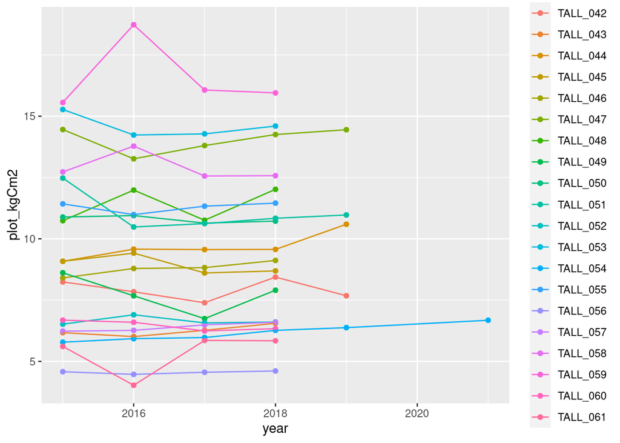

```r
 plot_live_carbon <-  tree_live_carbon %>%
    mutate(treeC_kgCm2 = (tree_kgC)/(totalSampledAreaTrees))  %>%
    group_by(plotID, year) %>%
    summarise(plot_kgCm2 = sum(treeC_kgCm2, na.rm = TRUE))
ggplot(plot_live_carbon, aes(x = year, y = plot_kgCm2, color = plotID)) +
  geom_point() +
  geom_line()
```

```r
 site_live_carbon <- plot_live_carbon %>%
    group_by(year) %>%
    summarize(mean_kgCperm2 = mean(plot_kgCm2, na.rm = TRUE),
              sd_kgCperm2 = sd(plot_kgCm2))
```

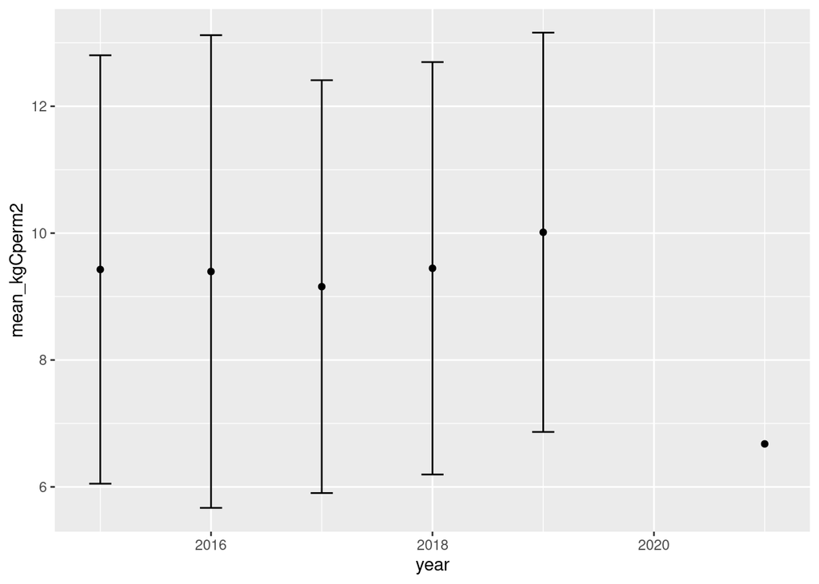

```r
ggplot(site_live_carbon, aes(x = year, y = mean_kgCperm2)) +
  geom_point() +
  geom_errorbar(aes(ymin=mean_kgCperm2-sd_kgCperm2, ymax=mean_kgCperm2+sd_kgCperm2), width=.2,
                 position=position_dodge(0.05))
```

# Calculate carbon in dead trees

We will now use `allodb` to extract the carbon in dead trees.

```r
combined_table_dead_tower <- combined_table_dbh %>%
  mutate(year = year(date)) %>%
  filter(grepl("Standing dead",plantStatus),
         plotType == "tower")
```

Calculate the biomass of each tree in the table

```r
tree_dead_carbon <- combined_table_dead_tower %>%
    mutate(ag_tree_kg = get_biomass(
          dbh = combined_table_dead_tower$stemDiameter,
          genus = combined_table_dead_tower$GENUS,
          species = combined_table_dead_tower$SPECIES,
          coords = c(-87.3, 34.2)
          ),
         bg_tree_kg = ag_tree_kg * ag_bg_prop,
         tree_kgC = (ag_tree_kg + bg_tree_kg) * 0.5)
```

Calculate the plot level biomass

```r
 plot_dead_carbon <-  tree_dead_carbon %>%
    mutate(treeC_kgCm2 = (tree_kgC)/(totalSampledAreaTrees))  %>%
    group_by(plotID, year) %>%
    summarise(plot_kgCm2 = sum(treeC_kgCm2, na.rm = TRUE))
 site_dead_carbon <- plot_dead_carbon %>%
    group_by(year) %>%
    summarize(mean_kgCperm2 = mean(plot_kgCm2, na.rm = TRUE),
              sd_kgCperm2 = sd(plot_kgCm2))
```

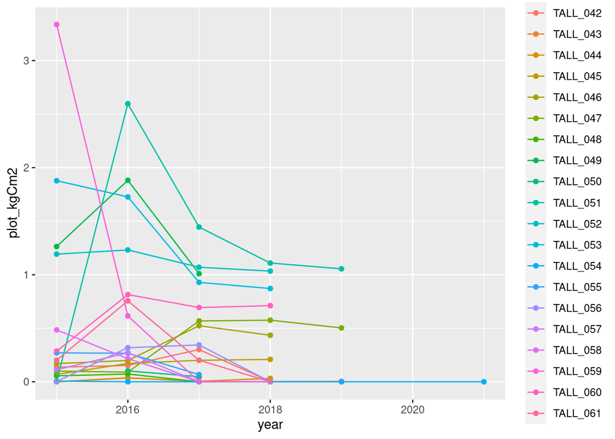

```r
ggplot(plot_dead_carbon, aes(x = year, y = plot_kgCm2, color = plotID)) +
  geom_point() +
  geom_line()
```

# Calculate carbon in dead trees on the ground

```r
#Download bieogeochemistry soil data to get carbon concentration
data_product1 <- "DP1.10014.001"
#Download physical soil data to get bulk density
data_product2 <- "DP1.10010.001"
```

```r
site <- "TALL"
## use neon_download to get desired data products
neon_download(product = data_product1, site = site)
```

```
##   comparing hashes against local file index...
```

```
##   omitting 22 files previously downloaded
```

```r
neon_download(product = data_product2, site = site)
```

```
##   comparing hashes against local file index...
```

```
##   omitting 13 files previously downloaded
```

```r
print(unique(neon_index(site = site)$table))
```

```
##  [1] "validation"                     "categoricalCodes"
##  [3] "EML"                            "mgp_perarchivesample-basic"
##  [5] "mgp_perbiogeosample-basic"      "mgp_perbulksample-basic"
##  [7] "mgp_perhorizon-basic"           "mgp_permegapit-basic"
##  [9] "readme"                         "variables"
## [11] "cdw_fieldtally-basic"           "cdw_densitydisk-basic"
## [13] "cdw_densitylog-basic"           "ltr_chemistrySubsampling-basic"
## [15] "ltr_fielddata-basic"            "ltr_litterCarbonNitrogen-basic"
## [17] "ltr_litterLignin-basic"         "ltr_massdata-basic"
## [19] "ltr_pertrap-basic"              "bbc_chemistryPooling-basic"
## [21] "bbc_dilution-basic"             "bbc_percore-basic"
## [23] "bbc_rootChemistry-basic"        "bbc_rootmass-basic"
## [25] "vst_apparentindividual-basic"   "vst_mappingandtagging-basic"
## [27] "vst_perplotperyear-basic"       "vst_shrubgroup-basic"
## [29] "nsae-basic"
```

```r
## Download bieogeochemistry soil data to get carbon concentration
data_product1 <- "DP1.10014.001"
site <- "TALL"
## use neon_download to get desired data products
neon_download(product = data_product1, site = site)
```

```
##   comparing hashes against local file index...
```

```
##   omitting 22 files previously downloaded
```

```r
print(unique(neon_index(product = data_product1, site = site)$table))
```

```
## [1] "cdw_densitydisk-basic" "cdw_densitylog-basic"  "EML"
## [4] "readme"                "variables"
```

```r
data_product2 <- 'DP1.10010.001'
neon_download(product = data_product2, site = site)
```

```
##   comparing hashes against local file index...
```

```
##   omitting 13 files previously downloaded
```

```r
print(unique(neon_index(product = data_product2, site = site)$table))
```

```
## [1] "cdw_fieldtally-basic" "EML"                  "readme"
## [4] "variables"
```

```r
cdw_tally <- neon_read(table = 'cdw_fieldtally-basic', site = site)

cdw_density <- neon_read(table = 'cdw_densitydisk-basic', site = site)

log_table <- neon_read(table = 'cdw_densitylog-basic', site = site)

## filter by tower plot for log table
log_table_filter <- log_table %>%
  filter(plotType == "tower")

## filter by tower plot for cdw table
cdw_tally <- cdw_tally %>%
  filter(plotType == 'tower')

## create
log_table_filter$gcm3 <- rep(NA, nrow(log_table_filter))

## set site specific volume factor
site_volume_factor <- 5

for (i in 1:nrow(log_table_filter)){
  ## match log table sampleID to cdw density table sample ID
  ind <- which(cdw_density$sampleID == log_table_filter$sampleID[i])
  ## produce g/cm^3 by multiplying bulk density of disk by site volume factor
  log_table_filter$gcm3[i] <- mean(cdw_density$bulkDensDisk[ind]) * site_volume_factor
}

## table of coarse wood
site_cwd_carbon <- log_table_filter %>%
  group_by(plotID) %>%
  summarize(mean_kgCperm2 = .5 * sum(gcm3, na.rm = TRUE) * .1)

## print mean cwd
mean(site_cwd_carbon$mean_kgCperm2)
```

```
## [1] 0.3981204
```

# Calculate carbon in fine roots

Here we are going to calculate the carbon stored in fine roots using the root chemistry data product. We will calculate the carbon in both dead and alive roots. Though we are interested mostly in live roots, at the time of writing this, there the 2021 NEON data for our site does not have `rootStatus` data available. Thus we will use historical data to compute an estimate of the ratio, so that we don’t have to throw away perfectly good information.

```r
## root chemistry data product
roots_DP <- 'DP1.10067.001'
## set site
site = "TALL"
## use neon_download from neonstore to read in data
neon_download(product = 'DP1.10067.001', site = site)
```

```
##   comparing hashes against local file index...
```

```
##   omitting 29 files previously downloaded
```

```r
## print available datasets from product
print(unique(neon_index(site = "TALL", product = 'DP1.10067.001')$table))
```

```
## [1] "bbc_chemistryPooling-basic" "bbc_dilution-basic"
## [3] "bbc_percore-basic"          "bbc_rootChemistry-basic"
## [5] "bbc_rootmass-basic"         "EML"
## [7] "readme"                     "variables"
```

```r
## read in bbc_percore
bbc_percore <- neon_read('bbc_percore-basic', site = site, product = roots_DP)
## read in rootmass data
rootmass <- neon_read('bbc_rootmass-basic', site = site, product = roots_DP)
## extract year
rootmass$year = year(rootmass$collectDate)

## set variables for liveDryMass, deadDryMass, unkDryMass, area
rootmass$liveDryMass <- rep(0, nrow(rootmass))
rootmass$deadDryMass <- rep(0, nrow(rootmass))
rootmass$unkDryMass <- rep(0, nrow(rootmass))
rootmass$area <- rep(NA, nrow(rootmass))
```

```r
for (i in 1:nrow(rootmass)){
  ## match by sample ID
  ind <- which(bbc_percore$sampleID == rootmass$sampleID[i])
  ## extract core sample area
  rootmass$area[i] <- bbc_percore$rootSampleArea[ind]
  ## categorize mass as live, dead, or unknown
  if (is.na(rootmass$rootStatus[i])){
    rootmass$unkDryMass[i] <- rootmass$dryMass[i]
  } else if (rootmass$rootStatus[i] == 'live'){
    rootmass$liveDryMass[i] <- rootmass$dryMass[i]
  } else if (rootmass$rootStatus[i] == 'dead'){
    rootmass$deadDryMass[i] <- rootmass$dryMass[i]
  } else{
    rootmass$unkDryMass[i] <- rootmass$dryMass[i]
  }
}
```

```r
## aggregate at plot and year level
## convert to kg (/1000) and carbon (.5)
site_roots <- rootmass %>%
  group_by(plotID, year) %>%
  summarize(mean_kgCperm2_live = .5*sum(liveDryMass/area, na.rm = TRUE)/1000,
            mean_kgCperm2_dead = .5*sum(deadDryMass/area, na.rm = TRUE)/1000,
            mean_kgCperm2_unk = .5*sum(unkDryMass/area, na.rm = TRUE)/1000)
mean(site_roots$mean_kgCperm2_live[which(site_roots$year == 2017)])
```

```
## [1] 1.34645
```

```r
mean(site_roots$mean_kgCperm2_dead[which(site_roots$year == 2017)])
```

```
## [1] 0.4293219
```

```r
mean(site_roots$mean_kgCperm2_unk[which(site_roots$year == 2017)])
```

```
## [1] 0
```

```r
mean(site_roots$mean_kgCperm2_live[which(site_roots$year == 2021)])
```

```
## [1] 0
```

```r
mean(site_roots$mean_kgCperm2_dead[which(site_roots$year == 2021)])
```

```
## [1] 0
```

```r
mean(site_roots$mean_kgCperm2_unk[which(site_roots$year == 2021)])
```

```
## [1] 1.687774
```

Then, we can look at the ratio of the carbon densities: $\rho_{live} = \frac{C_{live}}{C_{live} + C_{dead}}$ for 2017 and apply that to the data from 2021.

```r
c_dens_live2017 <- mean(site_roots$mean_kgCperm2_live[which(site_roots$year == 2017)])
c_dens_dead2017 <- mean(site_roots$mean_kgCperm2_dead[which(site_roots$year == 2017)])

rho <- c_dens_live2017 / (c_dens_live2017 + c_dens_dead2017)

approx_live_cdens_2021 <- rho * mean(site_roots$mean_kgCperm2_unk[which(site_roots$year == 2021)])
print(approx_live_cdens_2021)
```

```
## [1] 1.279727
```

# Calculate carbon in soils

```r
#Download bieogeochemistry soil data to get carbon concentration
#data_product1 <- "DP1.00097.001"
#Download physical soil data to get bulk density
data_product2 <- "DP1.00096.001"
```

```r
## use neon_download to extract data product
neon_download(product = data_product2, site = site)
```

```
##   comparing hashes against local file index...
```

```
##   omitting 9 files previously downloaded
```

```r
print(unique(neon_index(site = site)$table))
```

```
##  [1] "validation"                     "categoricalCodes"
##  [3] "EML"                            "mgp_perarchivesample-basic"
##  [5] "mgp_perbiogeosample-basic"      "mgp_perbulksample-basic"
##  [7] "mgp_perhorizon-basic"           "mgp_permegapit-basic"
##  [9] "readme"                         "variables"
## [11] "cdw_fieldtally-basic"           "cdw_densitydisk-basic"
## [13] "cdw_densitylog-basic"           "ltr_chemistrySubsampling-basic"
## [15] "ltr_fielddata-basic"            "ltr_litterCarbonNitrogen-basic"
## [17] "ltr_litterLignin-basic"         "ltr_massdata-basic"
## [19] "ltr_pertrap-basic"              "bbc_chemistryPooling-basic"
## [21] "bbc_dilution-basic"             "bbc_percore-basic"
## [23] "bbc_rootChemistry-basic"        "bbc_rootmass-basic"
## [25] "vst_apparentindividual-basic"   "vst_mappingandtagging-basic"
## [27] "vst_perplotperyear-basic"       "vst_shrubgroup-basic"
## [29] "nsae-basic"
```

```r
mgc_perbiogeosample <- neon_read('mgp_perbiogeosample', site = site)
mgp_perbulksample <- neon_read('mgp_perbulksample', site = site)
```

```r
bulk_density <- mgp_perbulksample %>%
    filter(bulkDensSampleType == "Regular") %>%
    select(horizonName,bulkDensExclCoarseFrag)

  #gramsPerCubicCentimeter
horizon_carbon <- mgc_perbiogeosample %>%
    filter(biogeoSampleType == "Regular") %>%
    select(horizonName,biogeoTopDepth,biogeoBottomDepth,carbonTot)
```

```r
  #Unit notes
  #bulkDensExclCoarseFrag = gramsPerCubicCentimeter
  #carbonTot = gramsPerKilogram

  #Combine and calculate the carbon of each horizon
horizon_combined <- inner_join(horizon_carbon,bulk_density, by = "horizonName") %>%
    #Convert volume in g per cm3 to mass per area in g per cm2 by multiplying by layer thickness
    mutate(horizon_soil_g_per_cm2 = (biogeoBottomDepth - biogeoTopDepth) * bulkDensExclCoarseFrag) %>%
    #Units of carbon are g per Kg soil but we have bulk density in g per cm2 so convert Kg soil to g soil
    mutate(CTot_g_per_g_soil = carbonTot*(1/1000),  #Units are g C per g soil
           horizon_C_g_percm2 = CTot_g_per_g_soil*horizon_soil_g_per_cm2, #Units are g C per cm2
           horizon_C_kg_per_m2 = horizon_C_g_percm2 * 10000 / 1000) %>% #Units are g C per m2
    select(-CTot_g_per_g_soil,-horizon_C_g_percm2) %>%
    arrange(biogeoTopDepth)

site_soil_carbon <- horizon_combined %>%
    summarize(soilC_gC_m2 = sum(horizon_C_kg_per_m2))
```

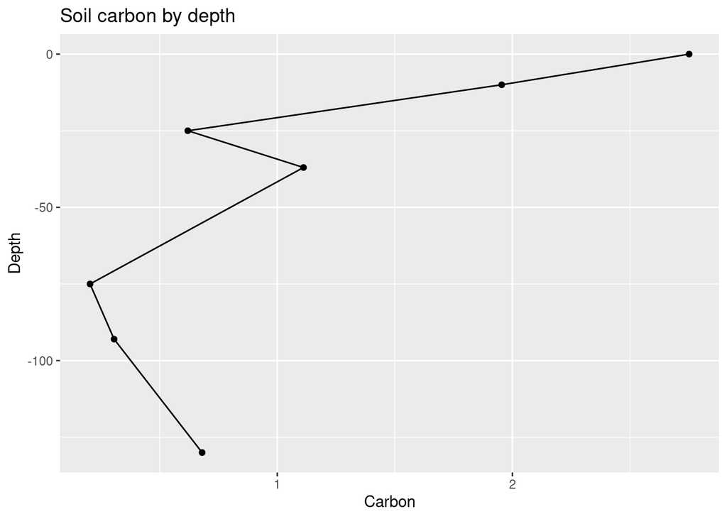

```r
ggplot(horizon_combined, map = aes(-biogeoTopDepth,horizon_C_kg_per_m2)) +
  geom_line() +
  geom_point() +
  labs(y = "Carbon", x = "Depth", title = "Soil carbon by depth") +
  coord_flip()
```

# Carbon Table

```r
total_carbon_components <- unlist(c(site_live_carbon$mean_kgCperm2[1],site_dead_carbon$mean_kgCperm2[1],mean(site_cwd_carbon$mean_kgCperm2),site_soil_carbon))

total_carbon_components <- c(total_carbon_components,sum(total_carbon_components))

names(total_carbon_components) <- c("Live Trees", "Standing Dead", "Down Coarse Wood", "Soil", "Total")

total_carbon_components
```

```
##       Live Trees    Standing Dead Down Coarse Wood             Soil
##        9.4269270        0.5036538        0.3981204        7.6257929
##            Total
##       17.9544941
```